# DataAnalysis_respirometry

Elliott Schmidt

2022-09-30

# Load libraries

```r
#--- load libraries ---#
library(tidyverse)
library(plyr)
library(dplyr)
library(lubridate)
library(ggplot2)
library(lme4)
library(nlme)
library(glmmTMB)
library(sjPlot)
library(gridExtra)
library(performance)
library(car)
library(DHARMa)
library(MuMIn)
library(broom)
library(emmeans)
library(ggeffects)
library(effects)
library(styler)
library(ggpubr)
```

# Set working directory

*Note:* working directory will be different for you and will depend on where you have saved files on local drive.

```r
knitr::opts_knit$set(root.dir = "C:/Users/Elliott/OneDrive - James Cook University/PhD dissertation/Data/Local_adaptation/Chapter1_LocalAdaptation")
```

# Summary

This is a common garden experiment where individual fish **(FISH_ID)** were exposed to four different **TEMPERATURE** treatments (i.e., 27, 28.5, 30, and 31.5). Fish sampled in this experiment were collected from three different sets of **POPULATIONS** that were collected from two different **REGIONS** (i.e., six different populations in total). REGIONS was used as block effect (as well as a fixed effect) with POPULATION as the within block effect.

Fish were first sampled at 27C and then subsequently at higher temperatures. Once all fish were tested at the set treatment temperature, the treatment temperature was increase 1.5C over three days. Fish were then given an additional five days to adjust to the temperature increase.

To determine the **MAX** metabolic rate fish were placed in a swim tunnel for ten minutes. The first five minutes were used to slowly increase the water flow within the swim tunnel until fish reached the point where fish would alternate between pectoral swimming and lateral body undulations (i.e., gait change). The water flow within the swim tunnel was maintained at gait change speeds for an additional five minutes. Afterwards fish were immediately placed within a designated repirometry **CHAMBER** with air saturation rates being monitored for 3.5-4 hours on a four minute measure, three minutes flush, and five second wait cycle.

Maximum metabolic rate was determined by extracting the steepest sixty second interval slope from the first (sometimes, but rarely, second or third) measurement period. **RESTING** metabolic rate was determined by extacrting the ten shallowest slopes that were recorded over the length of the experiment.

Fish were sampled in random order. The order that fish were sampled in determined the **SUMP**/**SYSTEM** fish run on as well as the chamber they were placed in (i.e., the first fish sampled went into chamber 1 on sump/system 1, the second fish into chamber 1 on sump/system 2, the third fish into chamber 2 on sump/system 1 etc.).

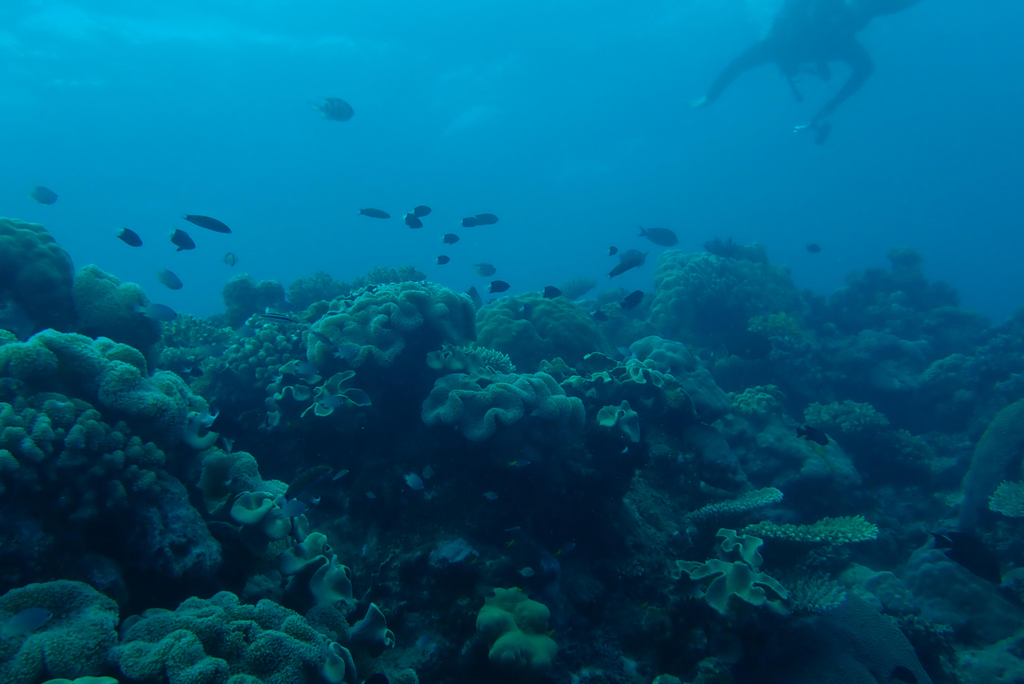

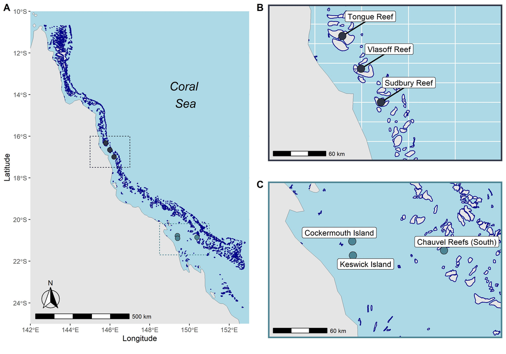

# Glossary of Terms

| **EXP_FISH_ID** | Combined FISH_ID with TEMPERATURE the fish was tested at |
| --- | --- |
| **FISH_ID** | Unique alphamueric code provided to fish |
| **POPULATION** | Population/Reef the fish was collected from |
| **REGION** | Region (i.e. core or leading) fish was collected from |
| **TEMPERATURE** | Temperature fish was tested at |
| **MASS** | Mass of the fish |
| **RESTING_DATE** | Date the resting metabolic rate was recorded for each fish |
| **RESTING_CHAMBER** | Respirometry chamber the fish was tested in for RMR |
| **RESTING_SYSTEM** | Respirometry system (i.e. dell or asus) fish was tests with |
| **RESTING_SUMP** | Respirometry sump (i.e., 1 or 2) fish was tested in |
| **RESTING_AM_PM** | Time of day (i.e. morning or afternoon) fish was tested |
| **RESTING_START_TIME** | Time that the fish was placed inside the repirometry chamber |
| **RESTING** | Resting metabolic rate (RMR) |
| **RESTING_MgO2.hr** | Resting metabolic rate divded mass |
| **MAX_DATE** | Date that maximum metabolic rate was recored |
| **MAX_CHAMBER** | Respirometry chamber the fish was tested in for MMR |
| **MAX_SYSTEM** | Respirometry system fish was test with for MMR |
| **MAX_SUMP** | Respirometry sump (i.e., 1 or 2) fish was tested in for MMR |
| **MAX_AM_PM** | Time of day (i.e. morning or afternoon) fish was tested for MMR |
| **MAX_START_TIME** | Time that the fish was placed inside the chamber for MMR |
| **MAX** | Maximum metabolic rate (MMR) |
| **MAX_MgO2.hr** | Maximum metabolic rate divided by mass |
| **FAS** | Factorial metabolic rate (MMR/RMR) |
| **NAS** | Net metabolic rate (MMR - RMR) |
| **MgO2.hr_Net** | Net metaboic rate divided by mass |
| **Swim.performance** | Fish swim performance in swim tunnel (i.e., good, okay, poor) |
| **Notes** | Additional experimental notes |
| **MASS_CENTERED** | Mass of fish (centered) |

# Import data

```r
resp <- read.delim("C:/Users/Elliott/OneDrive - James Cook University/PhD dissertation/Data/Local_adaptation/Chapter1_LocalAdaptation/respirometry/SummaryData_2022_resp.txt")

# data seems to have loaded with two extract columns at the end
# remove extract columns by name

resp <- resp %>% select(-c("X", "X.1"))
```

# Preparing data

```r
resp2 <- resp %>%
  dplyr::rename(EXP_FISH_ID = FISH_ID) %>%
  separate(EXP_FISH_ID, c("FISH_ID"), remove = FALSE) %>%
  mutate(
    FISH_ID = factor(FISH_ID),
    POPULATION = factor(POPULATION),
    REGION = factor(REGION),
    TEMPERATURE = as.numeric(TEMPERATURE),
    RESTING_DATE = factor(RESTING_DATE),
    RESTING_CHAMBER = factor(RESTING_CHAMBER),
    RESTING_SYSTEM = factor(RESTING_SYSTEM),
    RESTING_SUMP = factor(RESTING_SUMP),
    RESTING_AM_PM = factor(RESTING_AM_PM),
    RESTING_START_TIME = hms(RESTING_START_TIME),
    MAX_DATE = factor(MAX_DATE),
    MAX_CHAMBER = factor(MAX_CHAMBER),
    MAX_SYSTEM = factor(MAX_SYSTEM),
    MAX_SUMP = factor(MAX_SUMP),
    MAX_AM_PM = factor(MAX_AM_PM),
    MAX_START_TIME = hms(MAX_START_TIME),
    Swim.performance = factor(Swim.performance)
  ) %>%
  dplyr::rename(MASS = WEIGHT) %>%
  mutate(MASS_CENTERED = scale(MASS, scale = FALSE, center = TRUE))
```

## Results

### Resting Metabolic Rates

### Data quailty

Removing fish that died during the respirometry trials

```r
#--- remove individuals where data is irregular ---#
resp3 <- resp2 %>%
  subset(EXP_FISH_ID != "LCHA132_27" &
    EXP_FISH_ID != "LKES168_27" &
    EXP_FISH_ID != "LCHA113_30" &
    EXP_FISH_ID != "CSUD088_27" &
    EXP_FISH_ID != "CTON062_27")
```

### Exploratory data analysis

Checking to make sure data is normally distributed

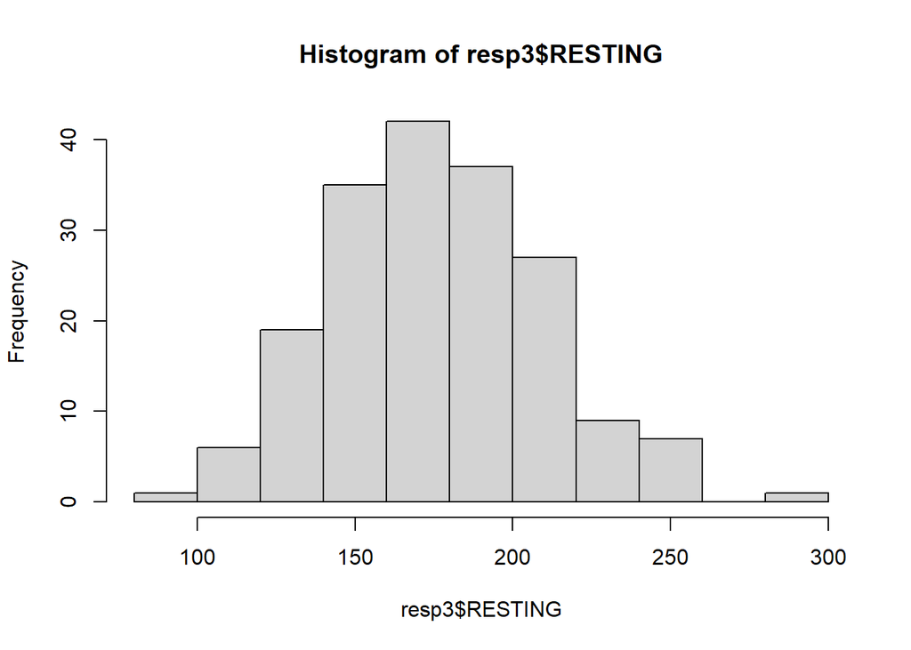

```r
hist(resp3$RESTING)
```

```r
shapiro.test(resp3$RESTING)
```

```
##
##  Shapiro-Wilk normality test
##
## data:  resp3$RESTING
## W = 0.98992, p-value = 0.221
```

### Descriptive statistics

```r
resp3 %>%
  group_by(REGION, TEMPERATURE) %>%
  dplyr::summarise(
    sample_size = n(),
    Min. = min(RESTING),
    Max. = max(RESTING),
    Mean = mean(RESTING)
  )
```

```
## # A tibble: 8 × 6
## # Groups:   REGION [2]
##   REGION  TEMPERATURE sample_size  Min.  Max.  Mean
##   <fct>         <dbl>       <int> <dbl> <dbl> <dbl>
## 1 Core           27            27  94.2  204.  159.
## 2 Core           28.5          28 103.   209.  161.
## 3 Core           30            25 124.   249.  168.
## 4 Core           31.5          22 144.   247.  185.
## 5 Leading        27            23 121.   209.  173.
## 6 Leading        28.5          22 116.   248.  181.
## 7 Leading        30            19 139.   228.  189.
## 8 Leading        31.5          18 145.   298.  206.
```

### Models

Linear, quardratic, and polynomial models were used to determine if a linear, quadratic, or polynomial regression fit the data the best. The co-variate **MASS** had its value centered before being included in the model to make the results more tangible. **RESTING_CHAMBER** and **RESTING_SUMP** co-variates were included within the model as well to account for any variation that may have come from different systems or chambers. Lastly, for random effects **POPULATION** was nested within **REGION**, and **FISH_ID** was also included as a random block.

```r
#--- model formula ---#
rest <- glmmTMB(RESTING ~ 1 + REGION * TEMPERATURE + MASS_CENTERED + RESTING_CHAMBER + RESTING_SUMP + (1 | REGION:POPULATION) + (1 | FISH_ID),
  family = gaussian(),
  data = resp3,
  REML = TRUE
)


rest.poly2 <- glmmTMB(RESTING ~ 1 + REGION * poly(TEMPERATURE, 2) + MASS_CENTERED + RESTING_CHAMBER + RESTING_SUMP + (1 | REGION:POPULATION) + (1 | FISH_ID),
  family = gaussian(),
  data = resp3,
  REML = TRUE
)

rest.poly3 <- glmmTMB(RESTING ~ 1 + REGION * poly(TEMPERATURE, 3) + MASS_CENTERED + RESTING_CHAMBER + RESTING_SUMP + (1 | REGION:POPULATION) + (1 | FISH_ID),
  family = gaussian(),
  data = resp3,
  REML = TRUE
)
```

### Model comparison

```r
AICc(rest, rest.poly2, rest.poly3, k = 2, REML = TRUE)
```

```
##            df     AICc
## rest       12 1699.086
## rest.poly2 14 1668.597
## rest.poly3 16 1655.069
```

The polynomial regression has the lowest AIC score and was therefore picked as the best model.

### Model performance checks

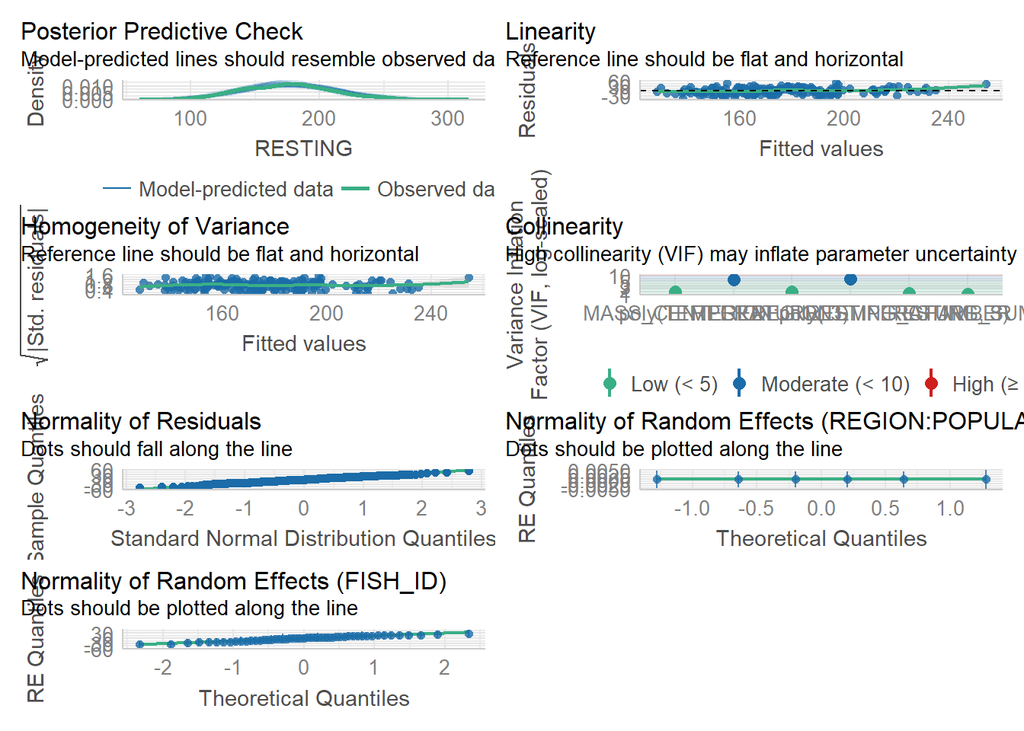

```r
check_model(rest.poly3)
```

Everything looks good

### Model investigation

Predicted values

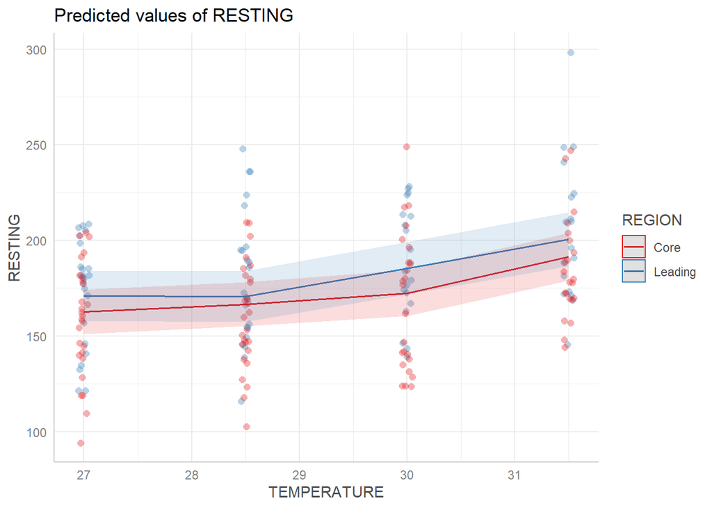

```r
rest.poly3 %>%
  ggemmeans(~ TEMPERATURE | REGION) %>%
  plot(add.data = TRUE, jitter = c(0.05, 0))
```

Mass shown to be influential on RESTING METABOLIC RATES

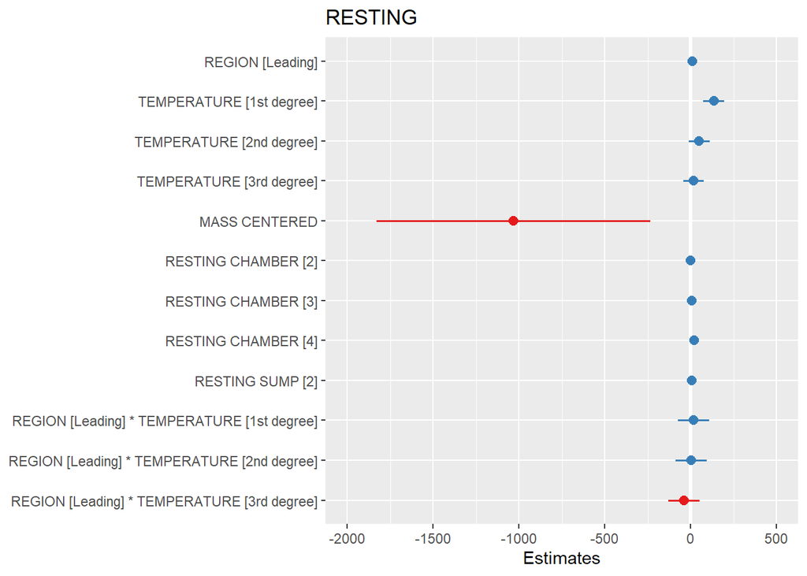

```r
rest.poly3 %>% plot_model(type = "est")
```

### Summary

```r
rest.poly3 %>% summary()
```

```
##  Family: gaussian  ( identity )
## Formula:
## RESTING ~ 1 + REGION * poly(TEMPERATURE, 3) + MASS_CENTERED +
##     RESTING_CHAMBER + RESTING_SUMP + (1 | REGION:POPULATION) +
##     (1 | FISH_ID)
## Data: resp3
##
##      AIC      BIC   logLik deviance df.resid
##   1651.8   1703.3   -809.9   1619.8      181
##
## Random effects:
##
## Conditional model:
##  Groups            Name        Variance  Std.Dev.
##  REGION:POPULATION (Intercept) 4.684e-06  0.002164
##  FISH_ID           (Intercept) 3.513e+02 18.743644
##  Residual                      4.963e+02 22.278316
## Number of obs: 184, groups:  REGION:POPULATION, 6; FISH_ID, 51
##
## Dispersion estimate for gaussian family (sigma^2):  496
##
## Conditional model:
##                                      Estimate Std. Error z value Pr(>|z|)
## (Intercept)                           162.374      6.001  27.058  < 2e-16 ***
## REGIONLeading                           8.476      7.592   1.116 0.264252
## poly(TEMPERATURE, 3)1                 134.229     30.762   4.363 1.28e-05 ***
## poly(TEMPERATURE, 3)2                  50.104     30.776   1.628 0.103521
## poly(TEMPERATURE, 3)3                  17.413     30.133   0.578 0.563342
## MASS_CENTERED                       -1030.580    406.450  -2.536 0.011227 *
## RESTING_CHAMBER2                        0.661      5.333   0.124 0.901363
## RESTING_CHAMBER3                        6.863      5.236   1.311 0.189929
## RESTING_CHAMBER4                       19.752      5.416   3.647 0.000265 ***
## RESTING_SUMP2                           6.640      3.788   1.753 0.079640 .
## REGIONLeading:poly(TEMPERATURE, 3)1    18.264     46.479   0.393 0.694353
## REGIONLeading:poly(TEMPERATURE, 3)2     3.200     46.781   0.068 0.945473
## REGIONLeading:poly(TEMPERATURE, 3)3   -39.609     46.223  -0.857 0.391501
## ---
## Signif. codes:  0 '***' 0.001 '**' 0.01 '*' 0.05 '.' 0.1 ' ' 1
```

### Confidence intervals

```r
rest.poly3 %>% confint()
```

```
##                                               2.5 %     97.5 %      Estimate
## (Intercept)                             150.6122718  174.13572  1.623740e+02
## REGIONLeading                            -6.4044919   23.35624  8.475874e+00
## poly(TEMPERATURE, 3)1                    73.9362210  194.52264  1.342294e+02
## poly(TEMPERATURE, 3)2                   -10.2159763  110.42358  5.010380e+01
## poly(TEMPERATURE, 3)3                   -41.6465702   76.47363  1.741353e+01
## MASS_CENTERED                         -1827.2076173 -233.95132 -1.030579e+03
## RESTING_CHAMBER2                         -9.7922105   11.11425  6.610179e-01
## RESTING_CHAMBER3                         -3.3987400   17.12399  6.862624e+00
## RESTING_CHAMBER4                          9.1367564   30.36716  1.975196e+01
## RESTING_SUMP2                            -0.7848952   14.06527  6.640190e+00
## REGIONLeading:poly(TEMPERATURE, 3)1     -72.8336305  109.36213  1.826425e+01
## REGIONLeading:poly(TEMPERATURE, 3)2     -88.4888944   94.88782  3.199463e+00
## REGIONLeading:poly(TEMPERATURE, 3)3    -130.2048224   50.98738 -3.960872e+01
## Std.Dev.(Intercept)|REGION:POPULATION     0.0000000        Inf  2.164165e-03
## Std.Dev.(Intercept)|FISH_ID              14.1292592   24.86501  1.874364e+01
```

### R-squared values

```r
rest.poly3 %>% r.squaredGLMM()
```

```
##            R2m       R2c
## [1,] 0.2975314 0.5886833
```

The r-squared values based on fixed effects (0.29) accounts of half the amount of variance as the same model when random effects are included (0.588). However, from the summary we can see that **POPULATION** account for little variation. Thus showing that variation between different fish made up for a large amount of variation.

### Figure

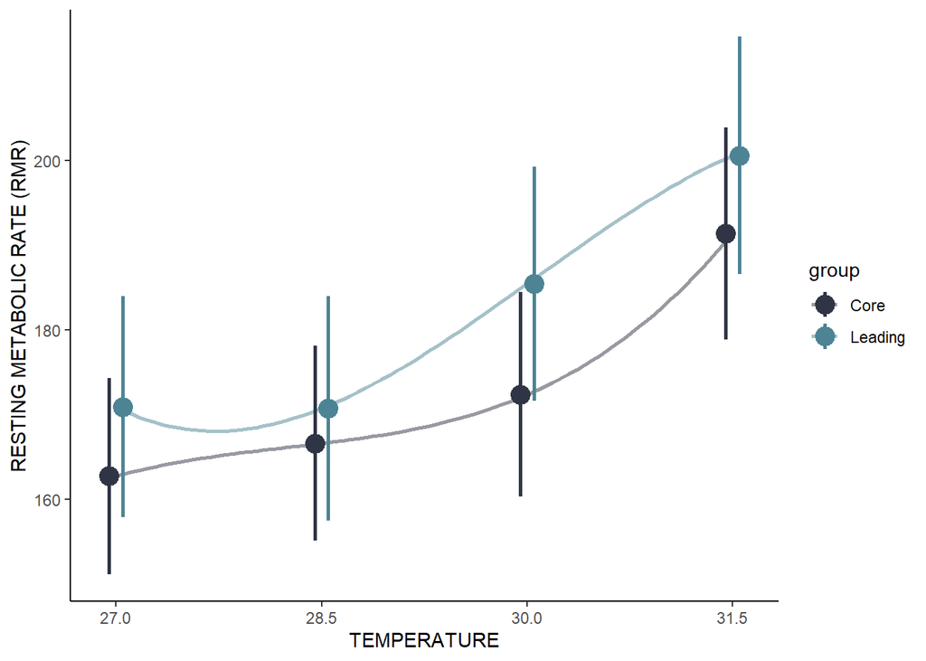

### Maximum Metabolic Rates

### Data quality

Removing fish that died during the respirometry trials. As well as fish that performed poorly for during max.

```r
#--- remove individuals where min.max data is unreliable ---#
resp3 <- resp2 %>%
  subset(EXP_FISH_ID != "LCHA132_27" &
    EXP_FISH_ID != "LKES168_27" &
    EXP_FISH_ID != "LCHA113_30" &
    EXP_FISH_ID != "CSUD088_27" &
    EXP_FISH_ID != "CTON062_27")

#--- remove individuals where ONLY max data is unreliable ---#
resp4 <- resp3 %>%
  subset(EXP_FISH_ID != "CSUD014_27" &
    EXP_FISH_ID != "CTON065_27" &
    EXP_FISH_ID != "CTON069_30" &
    EXP_FISH_ID != "CVLA054_27" &
    EXP_FISH_ID != "LCHA129_27" &
    EXP_FISH_ID != "LCHA135_27" &
    EXP_FISH_ID != "LCKM162_27" &
    EXP_FISH_ID != "LCKM165_27" &
    EXP_FISH_ID != "LCKM180_27" &
    EXP_FISH_ID != "CSUD026_30" &
    EXP_FISH_ID != "CTON067_28.5" &
    EXP_FISH_ID != "CVLA054_28.5" &
    EXP_FISH_ID != "LCHA114_28.5" &
    EXP_FISH_ID != "LCKM163_28.5" &
    EXP_FISH_ID != "LCKM154_31.5" &
    EXP_FISH_ID != "CSUD079_30" &
    EXP_FISH_ID != "CSUD079_31.5" &
    EXP_FISH_ID != "LCHA125_30")
```

### Exploratory data analysis

Checking to make sure data is normally distributed

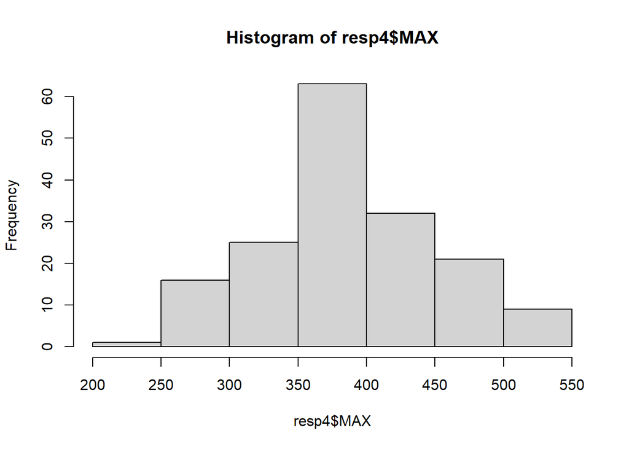

```r
hist(resp4$MAX)
```

```r
shapiro.test(resp4$MAX)
```

```
##
##  Shapiro-Wilk normality test
##
## data:  resp4$MAX
## W = 0.98794, p-value = 0.1627
```

### Descriptive statistics

```r
resp4 %>%
  group_by(REGION, TEMPERATURE) %>%
  dplyr::summarise(
    sample_size = n(),
    Min. = min(MAX),
    Max. = max(MAX),
    Mean = mean(MAX)
  )
```

```
## # A tibble: 8 × 6
## # Groups:   REGION [2]
##   REGION  TEMPERATURE sample_size  Min.  Max.  Mean
##   <fct>         <dbl>       <int> <dbl> <dbl> <dbl>
## 1 Core           27            24  264.  523.  358.
## 2 Core           28.5          26  291.  456.  385.
## 3 Core           30            22  341.  473.  407.
## 4 Core           31.5          21  295.  542.  411.
## 5 Leading        27            19  255.  537.  364.
## 6 Leading        28.5          20  244.  536.  389.
## 7 Leading        30            18  305.  524.  398.
## 8 Leading        31.5          17  274.  525.  392.
```

### Models

Linear, quardratic, and polynomial models were used to determine if a linear, quadratic, or polynomial regression fit the data the best. The co-variate **MASS** had its value centered before being included in the model to make the results more tangible. **MAX_CHAMBER** and **MAX_SUMP** co-variates were included within the model as well to account for any variation that may have come from different systems or chambers. Lastly, for random effects **POPULATION** was nested within **REGION**, and **FISH_ID** was also included as a random block.

```r
# max metablic rate
mmr <- glmmTMB(MAX ~ 1 + REGION * TEMPERATURE + MASS_CENTERED + MAX_CHAMBER + MAX_SUMP + (1 | REGION:POPULATION) + (1 | FISH_ID),
  family = gaussian(),
  data = resp4,
  REML = TRUE
)


mmr.p2 <- glmmTMB(MAX ~ 1 + REGION * poly(TEMPERATURE, 2) + MASS_CENTERED + MAX_CHAMBER + MAX_SUMP + (1 | REGION:POPULATION) + (1 | FISH_ID),
  family = gaussian(),
  data = resp4,
  REML = TRUE
)

mmr.p3 <- glmmTMB(MAX ~ 1 + REGION * poly(TEMPERATURE, 3) + MASS_CENTERED + MAX_CHAMBER + MAX_SUMP + (1 | REGION:POPULATION) + (1 | FISH_ID),
  family = gaussian(),
  data = resp4,
  REML = TRUE
)
```

### Model comparison

```r
#--- model compairson ---#
AICc(mmr, mmr.p2, mmr.p3, k = 2, REML = TRUE)
```

```
##        df     AICc
## mmr    12 1752.680
## mmr.p2 14 1723.097
## mmr.p3 16 1707.749
```

The polynomial regression has the lowest AIC score and was therefore picked as the best model.

### Model performance checks

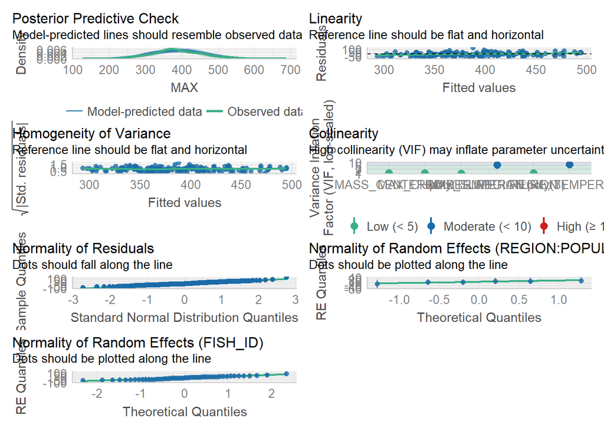

```r
check_model(mmr.p3)
```

Everything looks good

### Model investigation

Predicted values

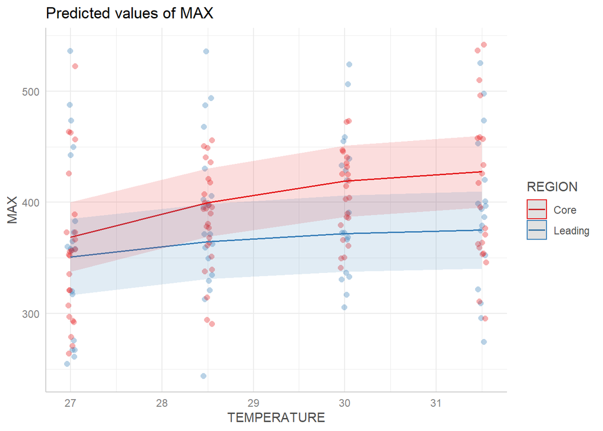

```r
mmr.p3 %>%
  ggemmeans(~ TEMPERATURE | REGION) %>%
  plot(add.data = TRUE, jitter = c(0.05, 0))
```

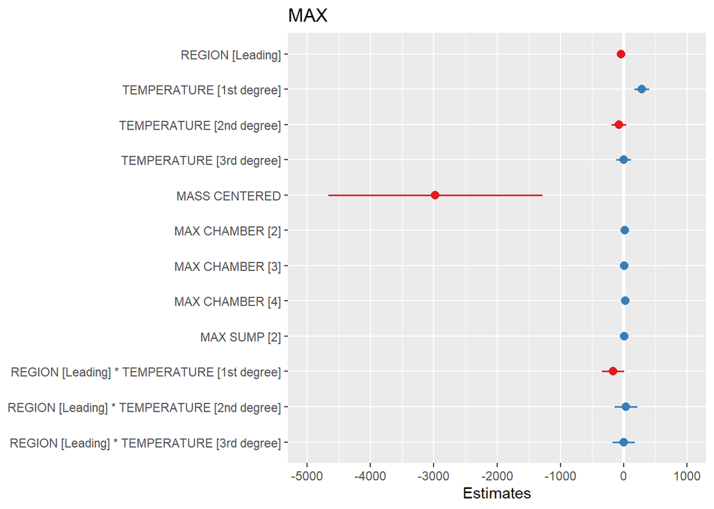

```r
mmr.p3 %>% plot_model(type = "est")
```

### Summary

```r
mmr.p3 %>% summary()
```

```
##  Family: gaussian  ( identity )
## Formula:
## MAX ~ 1 + REGION * poly(TEMPERATURE, 3) + MASS_CENTERED + MAX_CHAMBER +
##     MAX_SUMP + (1 | REGION:POPULATION) + (1 | FISH_ID)
## Data: resp4
##
##      AIC      BIC   logLik deviance df.resid
##   1704.1   1754.0   -836.1   1672.1      164
##
## Random effects:
##
## Conditional model:
##  Groups            Name        Variance Std.Dev.
##  REGION:POPULATION (Intercept)  295.7   17.20
##  FISH_ID           (Intercept) 1557.5   39.47
##  Residual                      1841.1   42.91
## Number of obs: 167, groups:  REGION:POPULATION, 6; FISH_ID, 51
##
## Dispersion estimate for gaussian family (sigma^2): 1.84e+03
##
## Conditional model:
##                                      Estimate Std. Error z value Pr(>|z|)
## (Intercept)                           383.469     16.549  23.171  < 2e-16 ***
## REGIONLeading                         -37.551     21.175  -1.773 0.076170 .
## poly(TEMPERATURE, 3)1                 282.035     59.881   4.710 2.48e-06 ***
## poly(TEMPERATURE, 3)2                 -72.313     59.474  -1.216 0.224035
## poly(TEMPERATURE, 3)3                   1.932     59.268   0.033 0.973993
## MASS_CENTERED                       -2976.208    863.300  -3.447 0.000566 ***
## MAX_CHAMBER2                           16.906     11.361   1.488 0.136733
## MAX_CHAMBER3                           12.859     11.180   1.150 0.250060
## MAX_CHAMBER4                           28.212     11.898   2.371 0.017738 *
## MAX_SUMP2                              10.210      8.171   1.250 0.211430
## REGIONLeading:poly(TEMPERATURE, 3)1  -167.321     90.716  -1.844 0.065118 .
## REGIONLeading:poly(TEMPERATURE, 3)2    37.386     92.493   0.404 0.686068
## REGIONLeading:poly(TEMPERATURE, 3)3     1.896     89.437   0.021 0.983090
## ---
## Signif. codes:  0 '***' 0.001 '**' 0.01 '*' 0.05 '.' 0.1 ' ' 1
```

### Confidence intervals

```r
mmr.p3 %>% confint()
```

```
##                                              2.5 %      97.5 %     Estimate
## (Intercept)                             351.033151   415.90488   383.469015
## REGIONLeading                           -79.053170     3.95149   -37.550840
## poly(TEMPERATURE, 3)1                   164.671344   399.39912   282.035233
## poly(TEMPERATURE, 3)2                  -188.879832    44.25445   -72.312689
## poly(TEMPERATURE, 3)3                  -114.231201   118.09564     1.932219
## MASS_CENTERED                         -4668.244361 -1284.17201 -2976.208188
## MAX_CHAMBER2                             -5.361254    39.17336    16.906054
## MAX_CHAMBER3                             -9.052807    34.77049    12.858839
## MAX_CHAMBER4                              4.891272    51.53234    28.211805
## MAX_SUMP2                                -5.803721    26.22423    10.210252
## REGIONLeading:poly(TEMPERATURE, 3)1    -345.120217    10.47908  -167.320569
## REGIONLeading:poly(TEMPERATURE, 3)2    -143.897843   218.66888    37.385519
## REGIONLeading:poly(TEMPERATURE, 3)3    -173.398517   177.18972     1.895602
## Std.Dev.(Intercept)|REGION:POPULATION     4.456778    66.35494    17.196780
## Std.Dev.(Intercept)|FISH_ID              29.341984    53.08208    39.465598
```

### R-squared values

```r
mmr.p3 %>% r.squaredGLMM()
```

```
##            R2m       R2c
## [1,] 0.2016554 0.6021365
```

The r-squared values based on fixed effects (0.20) accounts for a third of the amount of variance as the same model when random effects are included (0.60). However, from the summary we can see that **POPULATION** account for little variation compared to **FISH_ID**. Thus showing that variation between different fish made up for a large amount of variation.

### Figure

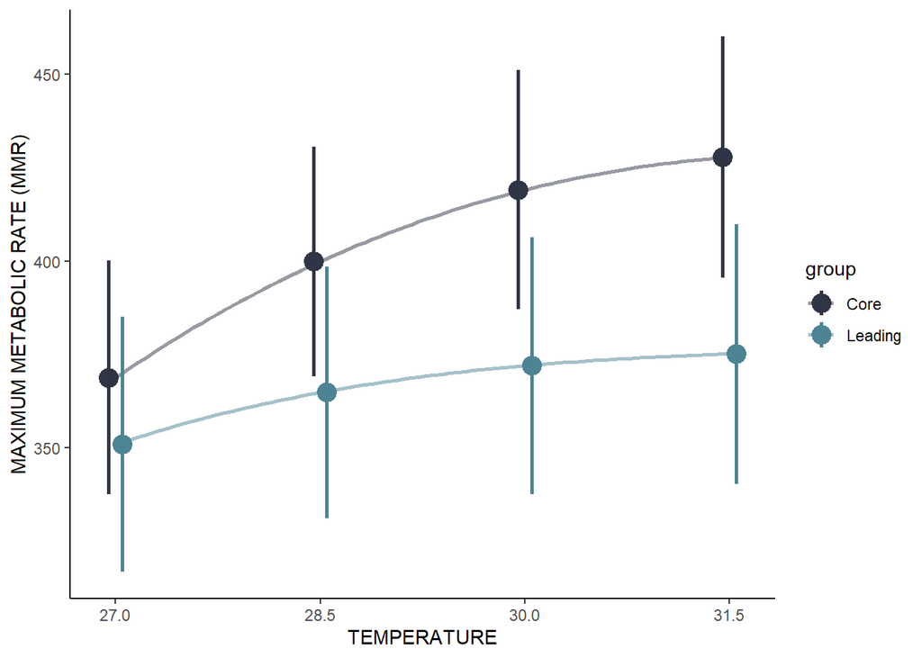

### Net Aerobic Scope

### Data quality

Removing fish that died during the respirometry trials. As well as fish that performed poorly for during NAS.

```r
#--- remove individuals where min.NAS data is unreliable ---#
resp3 <- resp2 %>%
  subset(EXP_FISH_ID != "LCHA132_27" &
    EXP_FISH_ID != "LKES168_27" &
    EXP_FISH_ID != "LCHA113_30" &
    EXP_FISH_ID != "CSUD088_27" &
    EXP_FISH_ID != "CTON062_27")

#--- remove individuals where ONLY NAS data is unreliable ---#
resp4 <- resp3 %>%
  subset(EXP_FISH_ID != "CSUD014_27" &
    EXP_FISH_ID != "CTON065_27" &
    EXP_FISH_ID != "CTON069_30" &
    EXP_FISH_ID != "CVLA054_27" &
    EXP_FISH_ID != "LCHA129_27" &
    EXP_FISH_ID != "LCHA135_27" &
    EXP_FISH_ID != "LCKM162_27" &
    EXP_FISH_ID != "LCKM165_27" &
    EXP_FISH_ID != "LCKM180_27" &
    EXP_FISH_ID != "CSUD026_30" &
    EXP_FISH_ID != "CTON067_28.5" &
    EXP_FISH_ID != "CVLA054_28.5" &
    EXP_FISH_ID != "LCHA114_28.5" &
    EXP_FISH_ID != "LCKM163_28.5" &
    EXP_FISH_ID != "LCKM154_31.5" &
    EXP_FISH_ID != "CSUD079_30" &
    EXP_FISH_ID != "CSUD079_31.5" &
    EXP_FISH_ID != "LCHA125_30")
```

### Exploratory data analysis

Checking to make sure data is normally distributed

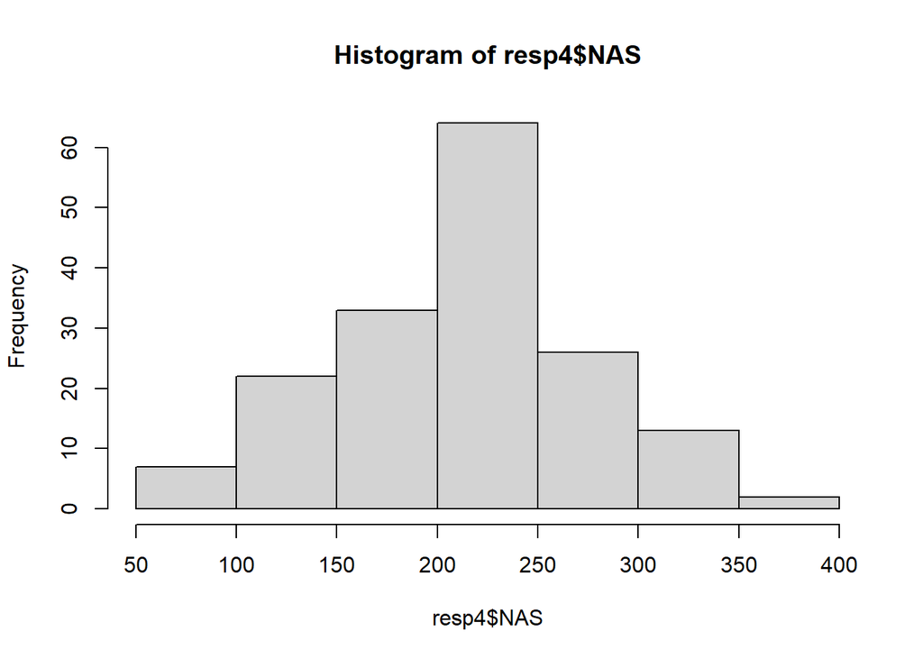

```r
hist(resp4$NAS)
```

```r
shapiro.test(resp4$NAS)
```

```
##
##  Shapiro-Wilk normality test
##
## data:  resp4$NAS
## W = 0.98525, p-value = 0.0747
```

### Descriptive statistics

```r
resp4 %>%
  group_by(REGION, TEMPERATURE) %>%
  dplyr::summarise(
    sample_size = n(),
    Min. = min(NAS),
    Max. = max(NAS),
    Mean = mean(NAS)
  )
```

```
## # A tibble: 8 × 6
## # Groups:   REGION [2]
##   REGION  TEMPERATURE sample_size  Min.  Max.  Mean
##   <fct>         <dbl>       <int> <dbl> <dbl> <dbl>
## 1 Core           27            24 106.   368.  197.
## 2 Core           28.5          26 124.   308.  225.
## 3 Core           30            22 162.   317.  242.
## 4 Core           31.5          21 117.   337.  227.
## 5 Leading        27            19  73.0  356.  194.
## 6 Leading        28.5          20  85    308.  204.
## 7 Leading        30            18 109.   323.  210.
## 8 Leading        31.5          17  86.2  273.  186.
```

### Models

Linear, quardratic, and polynomial models were used to determine if a linear, quadratic, or polynomial regression fit the data the best. The co-variate **MASS** had its value centered before being included in the model to make the results more tangible. **SUMP** co-variates was included within the model as well to account for any variation that may have come from different systems or chambers. Net aerobic scope relies on both resting and maximum metabolic rates, therefore **RESTING_CHAMBER** and **MAX_CHAMBER** were both used, however for the vast majority of fish the chamber number should be the same. The chamber number will mostly likely be different for fish tested at 27C, where resting and maximum metabolic rates were tested on different days, as well as for a handful at fish that performed poorly on their first run for max, and had to be tested again. Lastly, for random effects **POPULATION** was nested within **REGION**, and **FISH_ID** was also included as a random block.

```r
# net aerobic scope
nas <- glmmTMB(NAS ~ 1 + REGION * TEMPERATURE + MASS_CENTERED +
  RESTING_CHAMBER + RESTING_SUMP + MAX_CHAMBER + MAX_SUMP +
  (1 | REGION:POPULATION) + (1 | FISH_ID),
family = gaussian(),
data = resp4,
REML = TRUE
)


nas.p2 <- glmmTMB(NAS ~ 1 + REGION * poly(TEMPERATURE, 2) + MASS_CENTERED +
  RESTING_CHAMBER + RESTING_SUMP +
  MAX_CHAMBER + MAX_SUMP +
  (1 | REGION:POPULATION) + (1 | FISH_ID),
family = gaussian(),
data = resp4,
REML = TRUE
)

nas.p3 <- glmmTMB(NAS ~ 1 + REGION * poly(TEMPERATURE, 3) + MASS_CENTERED +
  RESTING_CHAMBER + RESTING_SUMP +
  MAX_CHAMBER + MAX_SUMP +
  (1 | REGION:POPULATION) + (1 | FISH_ID),
family = gaussian(),
data = resp4,
REML = TRUE
)
```

### Model comparison

```r
#--- model compairson ---#
AICc(nas, nas.p2, nas.p3, k = 2, REML = TRUE)
```

```
##        df     AICc
## nas    16 1746.576
## nas.p2 18 1712.716
## nas.p3 20 1697.120
```

The polynomial regression has the lowest AIC score and was therefore picked as the best model.

### Model performance checks

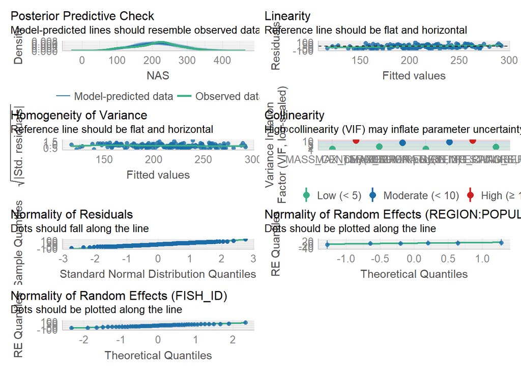

```r
check_model(nas.p3)
```

Everything looks good

### Model investigation

Predicted values

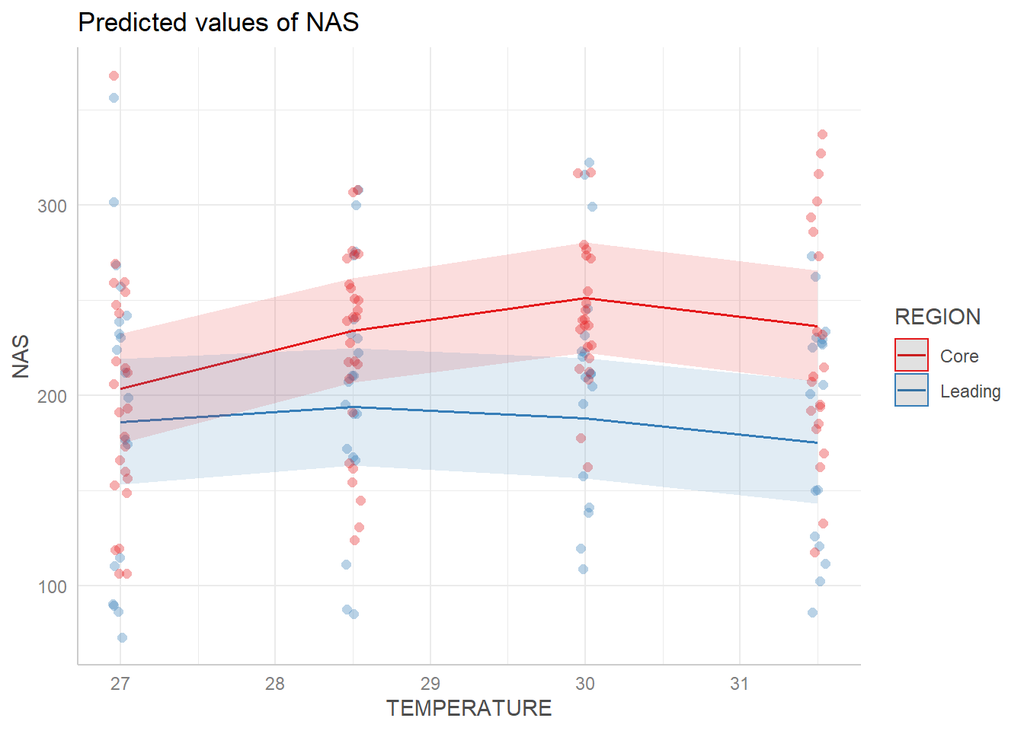

```r
nas.p3 %>%
  ggemmeans(~ TEMPERATURE | REGION) %>%
  plot(add.data = TRUE, jitter = c(0.05, 0))
```

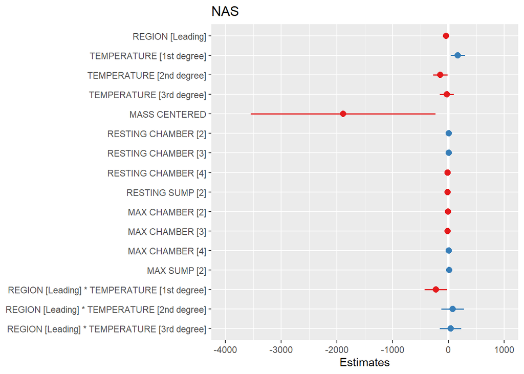

```r
nas.p3 %>% plot_model(type = "est")
```

### Summary

```r
nas.p3 %>% summary()
```

```
##  Family: gaussian  ( identity )
## Formula:
## NAS ~ 1 + REGION * poly(TEMPERATURE, 3) + MASS_CENTERED + RESTING_CHAMBER +
##     RESTING_SUMP + MAX_CHAMBER + MAX_SUMP + (1 | REGION:POPULATION) +
##     (1 | FISH_ID)
## Data: resp4
##
##      AIC      BIC   logLik deviance df.resid
##   1691.4   1753.7   -825.7   1651.4      164
##
## Random effects:
##
## Conditional model:
##  Groups            Name        Variance Std.Dev.
##  REGION:POPULATION (Intercept)  126.9   11.26
##  FISH_ID           (Intercept) 1399.1   37.40
##  Residual                      2111.8   45.95
## Number of obs: 167, groups:  REGION:POPULATION, 6; FISH_ID, 51
##
## Dispersion estimate for gaussian family (sigma^2): 2.11e+03
##
## Conditional model:
##                                      Estimate Std. Error z value Pr(>|z|)
## (Intercept)                           232.904     15.285  15.237  < 2e-16 ***
## REGIONLeading                         -44.655     18.251  -2.447  0.01442 *
## poly(TEMPERATURE, 3)1                 169.325     65.179   2.598  0.00938 **
## poly(TEMPERATURE, 3)2                -144.517     64.827  -2.229  0.02580 *
## poly(TEMPERATURE, 3)3                 -27.571     63.856  -0.432  0.66591
## MASS_CENTERED                       -1889.708    846.484  -2.232  0.02559 *
## RESTING_CHAMBER2                        8.961     16.917   0.530  0.59630
## RESTING_CHAMBER3                        9.217     17.432   0.529  0.59699
## RESTING_CHAMBER4                      -13.048     16.960  -0.769  0.44168
## RESTING_SUMP2                         -12.214     11.638  -1.049  0.29396
## MAX_CHAMBER2                           -4.862     17.143  -0.284  0.77670
## MAX_CHAMBER3                          -11.890     17.947  -0.663  0.50765
## MAX_CHAMBER4                            6.578     17.791   0.370  0.71158
## MAX_SUMP2                              11.214     12.512   0.896  0.37011
## REGIONLeading:poly(TEMPERATURE, 3)1  -222.666    102.726  -2.168  0.03019 *
## REGIONLeading:poly(TEMPERATURE, 3)2    77.846    103.373   0.753  0.45141
## REGIONLeading:poly(TEMPERATURE, 3)3    38.321     97.831   0.392  0.69528
## ---
## Signif. codes:  0 '***' 0.001 '**' 0.01 '*' 0.05 '.' 0.1 ' ' 1
```

### Confidence intervals

```r
nas.p3 %>% confint()
```

```
##                                              2.5 %      97.5 %     Estimate
## (Intercept)                             202.944734  262.862287   232.903511
## REGIONLeading                           -80.425355   -8.883951   -44.654653
## poly(TEMPERATURE, 3)1                    41.575288  297.074108   169.324698
## poly(TEMPERATURE, 3)2                  -271.574615  -17.458385  -144.516500
## poly(TEMPERATURE, 3)3                  -152.727029   97.584980   -27.571025
## MASS_CENTERED                         -3548.785831 -230.630065 -1889.707948
## RESTING_CHAMBER2                        -24.194898   42.117527     8.961314
## RESTING_CHAMBER3                        -24.949391   43.383121     9.216865
## RESTING_CHAMBER4                        -46.288787   20.192276   -13.048255
## RESTING_SUMP2                           -35.024644   10.596568   -12.214038
## MAX_CHAMBER2                            -38.461928   28.737627    -4.862150
## MAX_CHAMBER3                            -47.065821   23.285649   -11.890086
## MAX_CHAMBER4                            -28.292482   41.448524     6.578021
## MAX_SUMP2                               -13.309168   35.737840    11.214336
## REGIONLeading:poly(TEMPERATURE, 3)1    -424.004658  -21.326799  -222.665728
## REGIONLeading:poly(TEMPERATURE, 3)2    -124.761831  280.454511    77.846340
## REGIONLeading:poly(TEMPERATURE, 3)3    -153.425341  230.066478    38.320568
## Std.Dev.(Intercept)|REGION:POPULATION     1.290993   98.282071    11.264168
## Std.Dev.(Intercept)|FISH_ID              26.867798   52.071999    37.404010
```

### R-squared values

```r
nas.p3 %>% r.squaredGLMM()
```

```
##            R2m       R2c
## [1,] 0.1457361 0.5040743
```

### Figure

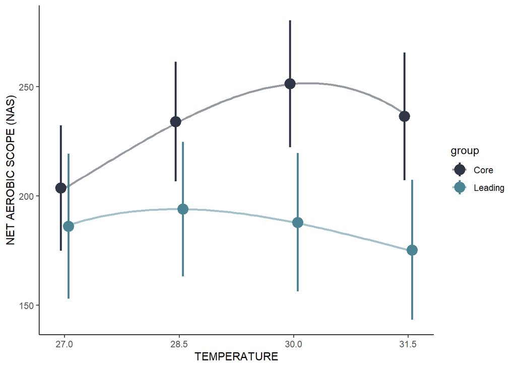

### Factorial Aerobic Scope

### Data quality

Removing fish that died during the respirometry trials. As well as fish that performed poorly for during FAS.

```r
#--- remove individuals where min.FAS data is unreliable ---#
resp3 <- resp2 %>%
  subset(EXP_FISH_ID != "LCHA132_27" &
    EXP_FISH_ID != "LKES168_27" &
    EXP_FISH_ID != "LCHA113_30" &
    EXP_FISH_ID != "CSUD088_27" &
    EXP_FISH_ID != "CTON062_27")

#--- remove individuals where ONLY FAS data is unreliable ---#
resp4 <- resp3 %>%
  subset(EXP_FISH_ID != "CSUD014_27" &
    EXP_FISH_ID != "CTON065_27" &
    EXP_FISH_ID != "CTON069_30" &
    EXP_FISH_ID != "CVLA054_27" &
    EXP_FISH_ID != "LCHA129_27" &
    EXP_FISH_ID != "LCHA135_27" &
    EXP_FISH_ID != "LCKM162_27" &
    EXP_FISH_ID != "LCKM165_27" &
    EXP_FISH_ID != "LCKM180_27" &
    EXP_FISH_ID != "CSUD026_30" &
    EXP_FISH_ID != "CTON067_28.5" &
    EXP_FISH_ID != "CVLA054_28.5" &
    EXP_FISH_ID != "LCHA114_28.5" &
    EXP_FISH_ID != "LCKM163_28.5" &
    EXP_FISH_ID != "LCKM154_31.5" &
    EXP_FISH_ID != "CSUD079_30" &
    EXP_FISH_ID != "CSUD079_31.5" &
    EXP_FISH_ID != "LCHA125_30")
```

### Exploratory data analysis

Checking to make sure data is normally distributed

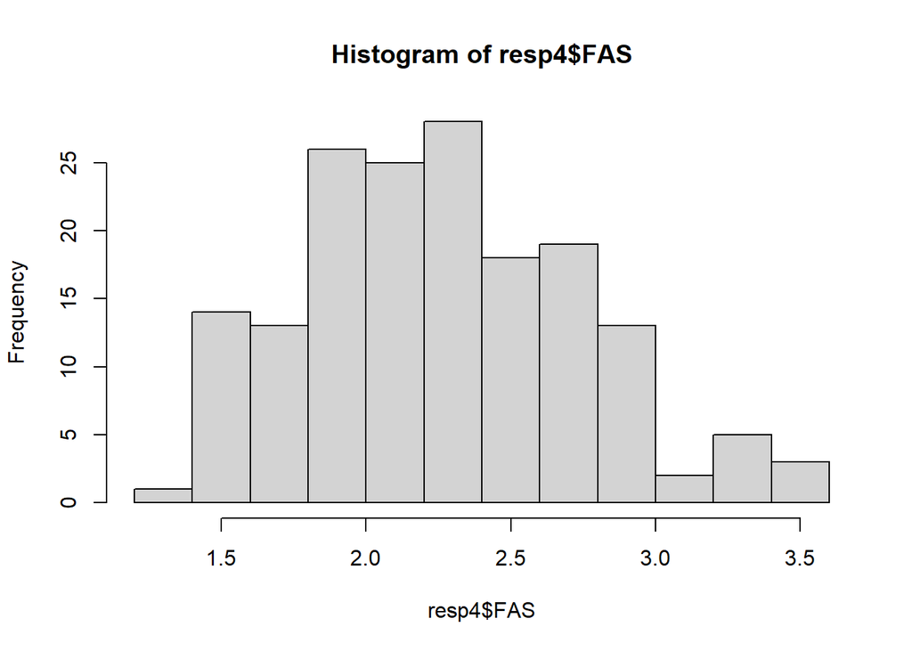

```r
hist(resp4$FAS)
```

```r
shapiro.test(resp4$FAS)
```

```
##
##  Shapiro-Wilk normality test
##
## data:  resp4$FAS
## W = 0.98165, p-value = 0.02623
```

### Descriptive statistics

```r
resp4 %>%
  group_by(REGION, TEMPERATURE) %>%
  dplyr::summarise(
    sample_size = n(),
    Min. = min(FAS),
    Max. = max(FAS),
    Mean = mean(FAS)
  )
```

```
## # A tibble: 8 × 6
## # Groups:   REGION [2]
##   REGION  TEMPERATURE sample_size  Min.  Max.  Mean
##   <fct>         <dbl>       <int> <dbl> <dbl> <dbl>
## 1 Core           27            24  1.59  3.39  2.26
## 2 Core           28.5          26  1.73  3.52  2.48
## 3 Core           30            22  1.91  3.56  2.54
## 4 Core           31.5          21  1.66  2.95  2.26
## 5 Leading        27            19  1.40  2.98  2.19
## 6 Leading        28.5          20  1.36  2.78  2.14
## 7 Leading        30            18  1.52  3.27  2.16
## 8 Leading        31.5          17  1.41  2.61  1.94
```

Data for **factorial aerobic scope** is **NOT** normally distributed. Instead it shows a right (positive) skew. I will figure out how to best model it later. For now I will proceed with just running the code with a normal distribution. It doesn’t look too far off.

### Models

Linear, quardratic, and polynomial models were used to determine if a linear, quadratic, or polynomial regression fit the data the best. The co-variate **MASS** had its value centered before being included in the model to make the results more tangible. **SUMP** co-variates was included within the model as well to account for any variation that may have come from different systems or chambers. Net aerobic scope relies on both resting and maximum metabolic rates, therefore **RESTING_CHAMBER** and **MAX_CHAMBER** were both used, however for the vast majority of fish the chamber number should be the same. The chamber number will mostly likely be different for fish tested at 27C, where resting and maximum metabolic rates were tested on different days, as well as for a handful at fish that performed poorly on their first run for max, and had to be tested again. Lastly, for random effects **POPULATION** was nested within **REGION**, and **FISH_ID** was also included as a random block.

```r
# factorial aerobic scope
fas <- glmmTMB(FAS ~ 1 + REGION * TEMPERATURE + MASS_CENTERED +
  RESTING_CHAMBER + RESTING_SUMP + MAX_CHAMBER + MAX_SUMP +
  (1 | REGION:POPULATION) + (1 | FISH_ID),
family = gaussian(),
data = resp4,
REML = TRUE
)


fas.p2 <- glmmTMB(FAS ~ 1 + REGION * poly(TEMPERATURE, 2) + MASS_CENTERED +
  RESTING_CHAMBER + RESTING_SUMP +
  MAX_CHAMBER + MAX_SUMP +
  (1 | REGION:POPULATION) + (1 | FISH_ID),
family = gaussian(),
data = resp4,
REML = TRUE
)

fas.p3 <- glmmTMB(FAS ~ 1 + REGION * poly(TEMPERATURE, 3) + MASS_CENTERED +
  RESTING_CHAMBER + RESTING_SUMP +
  MAX_CHAMBER + MAX_SUMP +
  (1 | REGION:POPULATION) + (1 | FISH_ID),
family = gaussian(),
data = resp4,
REML = TRUE
)
```

### Model comparison

```r
#--- model compairson ---#
AICc(fas, fas.p2, fas.p3, k = 2, REML = TRUE)
```

```
##        df     AICc
## fas    16 259.4514
## fas.p2 18 239.7221
## fas.p3 20 242.9715
```

The quadratic regression has the lowest AIC score and was therefore picked as the best model.

### Model performance checks

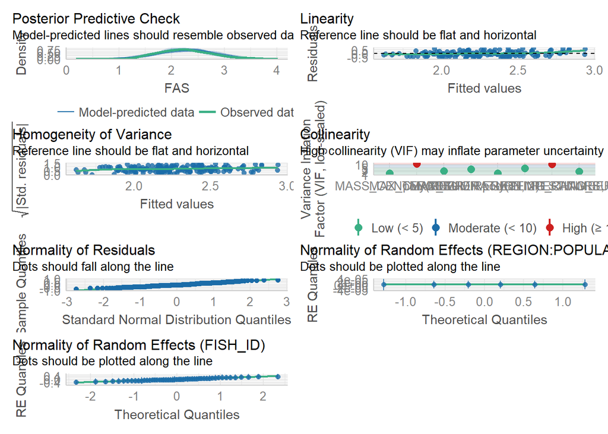

```r
check_model(fas.p2)
```

Everything looks good

### Model investigation

Predicted values

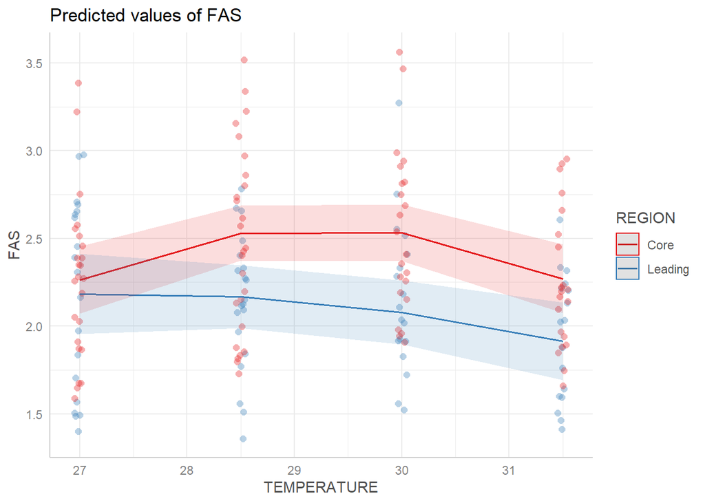

```r
fas.p2 %>%
  ggemmeans(~ TEMPERATURE | REGION) %>%
  plot(add.data = TRUE, jitter = c(0.05, 0))
```

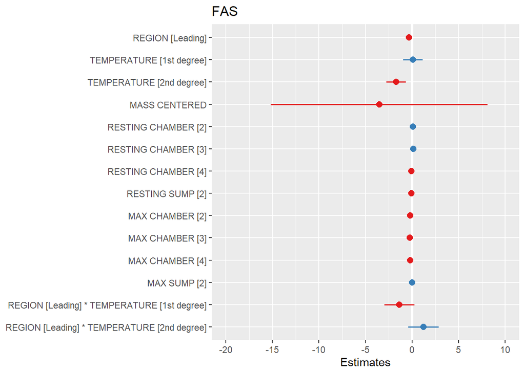

```r
fas.p2 %>% plot_model(type = "est")
```

### Summary

```r
fas.p2 %>% summary()
```

```
##  Family: gaussian  ( identity )
## Formula:
## FAS ~ 1 + REGION * poly(TEMPERATURE, 2) + MASS_CENTERED + RESTING_CHAMBER +
##     RESTING_SUMP + MAX_CHAMBER + MAX_SUMP + (1 | REGION:POPULATION) +
##     (1 | FISH_ID)
## Data: resp4
##
##      AIC      BIC   logLik deviance df.resid
##    235.1    291.2    -99.6    199.1      164
##
## Random effects:
##
## Conditional model:
##  Groups            Name        Variance  Std.Dev.
##  REGION:POPULATION (Intercept) 1.776e-10 1.333e-05
##  FISH_ID           (Intercept) 6.029e-02 2.455e-01
##  Residual                      1.419e-01 3.767e-01
## Number of obs: 167, groups:  REGION:POPULATION, 6; FISH_ID, 51
##
## Dispersion estimate for gaussian family (sigma^2): 0.142
##
## Conditional model:
##                                     Estimate Std. Error z value Pr(>|z|)
## (Intercept)                          2.55716    0.10532  24.281  < 2e-16 ***
## REGIONLeading                       -0.30966    0.11253  -2.752  0.00593 **
## poly(TEMPERATURE, 2)1                0.08292    0.53055   0.156  0.87581
## poly(TEMPERATURE, 2)2               -1.70444    0.52911  -3.221  0.00128 **
## MASS_CENTERED                       -3.53082    5.94455  -0.594  0.55254
## RESTING_CHAMBER2                     0.10878    0.13389   0.812  0.41651
## RESTING_CHAMBER3                     0.12610    0.13986   0.902  0.36727
## RESTING_CHAMBER4                    -0.08555    0.13508  -0.633  0.52653
## RESTING_SUMP2                       -0.09207    0.09419  -0.977  0.32833
## MAX_CHAMBER2                        -0.19764    0.13694  -1.443  0.14895
## MAX_CHAMBER3                        -0.23241    0.14475  -1.606  0.10837
## MAX_CHAMBER4                        -0.18472    0.14304  -1.291  0.19657
## MAX_SUMP2                            0.01612    0.10110   0.159  0.87334
## REGIONLeading:poly(TEMPERATURE, 2)1 -1.35639    0.83249  -1.629  0.10325
## REGIONLeading:poly(TEMPERATURE, 2)2  1.22219    0.83659   1.461  0.14404
## ---
## Signif. codes:  0 '***' 0.001 '**' 0.01 '*' 0.05 '.' 0.1 ' ' 1
```

### Confidence intervals

```r
fas.p2 %>% confint()
```

```
##                                             2.5 %      97.5 %      Estimate
## (Intercept)                             2.3507486  2.76357750  2.557163e+00
## REGIONLeading                          -0.5302042 -0.08910761 -3.096559e-01
## poly(TEMPERATURE, 2)1                  -0.9569322  1.12276793  8.291785e-02
## poly(TEMPERATURE, 2)2                  -2.7414819 -0.66739503 -1.704438e+00
## MASS_CENTERED                         -15.1819171  8.12028131 -3.530818e+00
## RESTING_CHAMBER2                       -0.1536286  0.37119093  1.087811e-01
## RESTING_CHAMBER3                       -0.1480260  0.40022484  1.260994e-01
## RESTING_CHAMBER4                       -0.3502926  0.17920119 -8.554570e-02
## RESTING_SUMP2                          -0.2766762  0.09253835 -9.206894e-02
## MAX_CHAMBER2                           -0.4660477  0.07076122 -1.976432e-01
## MAX_CHAMBER3                           -0.5161185  0.05130382 -2.324073e-01
## MAX_CHAMBER4                           -0.4650870  0.09563795 -1.847245e-01
## MAX_SUMP2                              -0.1820428  0.21427852  1.611786e-02
## REGIONLeading:poly(TEMPERATURE, 2)1    -2.9880433  0.27526409 -1.356390e+00
## REGIONLeading:poly(TEMPERATURE, 2)2    -0.4175010  2.86187427  1.222187e+00
## Std.Dev.(Intercept)|REGION:POPULATION   0.0000000         Inf  1.332614e-05
## Std.Dev.(Intercept)|FISH_ID             0.1667298  0.36161393  2.455439e-01
```

### R-squared values

```r
fas.p2 %>% r.squaredGLMM()
```

```
##            R2m       R2c
## [1,] 0.1828241 0.4264643
```

The r-squared values based on fixed effects (0.18) accounts for half of the amount of variance as the same model when random effects are included (0.43). However, from the summary we can see that **POPULATION** account for little variation compared to **FISH_ID**. Thus showing that variation between different fish made up for a large amount of variation.

### Figure

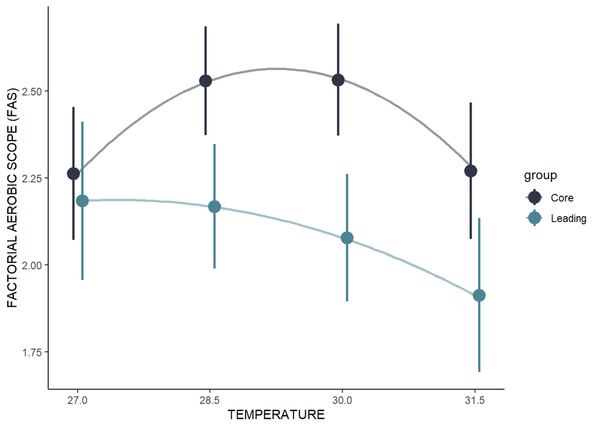

# General Summary

**RESTING METABOLIC RATE** and **MAXIMUM METABOLIC RATE** shows no significant difference within the temperature response curve between fish collected from the core region of the Great Barrier Reef and the sampled southern section (Mackay region) of the Great Barrier Reef.

Fish from the core and leading edge (mackay region) of the Great Barrier Reef showed similar thermal response curves. However, it looks like fish from the core region of the Great Barrier Reef overall performed better at high temperatures, but this will need to be confirmed with further analysis. Interestingly, fish from the core and leading edge regions appeared to optimally at temperatures that were +1.5 their normal range (i.e., core region function well at 30C, and leading edge fish function well at 28.5). Although performance appeared to drop at 31.5C, the drop in performance was not particularly sharp.

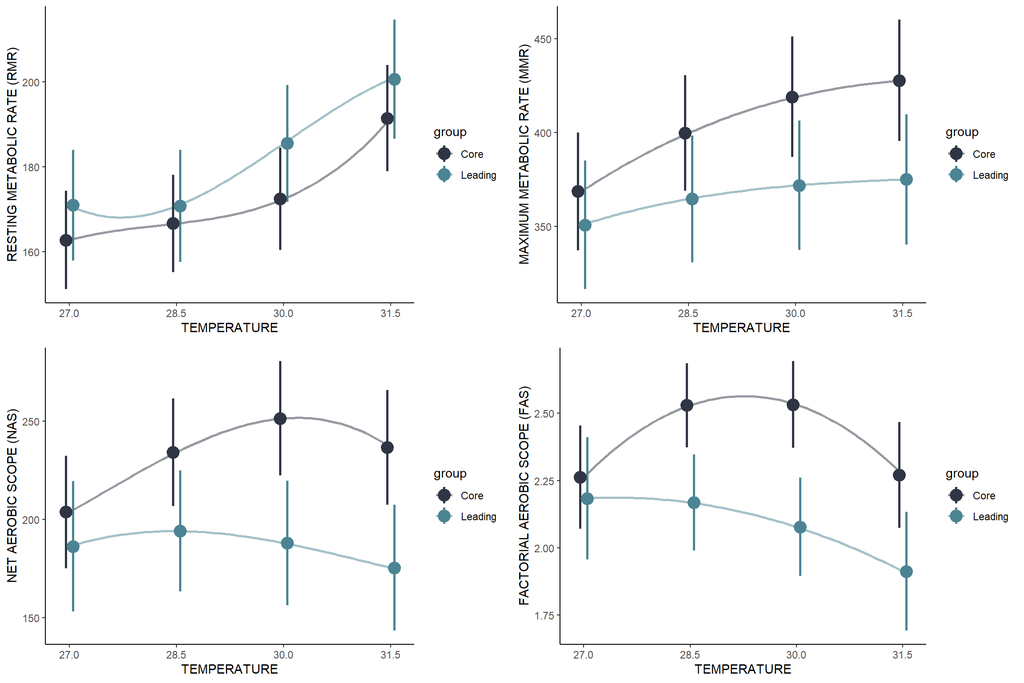